# How Long a Congressional Career Lasts, 1789–2025

Two-thirds of the newest careers have not finished, and the arithmetic that counts them anyway

Democracy’s Data

Last updated September 13, 2026 at 10:53a EDT

Congress is regularly described as a job nobody leaves: safe seats, career politicians, members who stay for decades. Is that true? How long does a congressional career actually last? The obvious way to answer is to take everybody who has ever served, count each person’s Congresses — the numbered two-year terms of the legislature, so that a member seated in January 2025 sits in the 119th — and average: a one-line calculation over 13,320 careers.

The answer that calculation gives is wrong, and wrong in a direction that reverses the finding. Done that way, the record says careers have been collapsing since the 1990s. Done properly, it says the opposite: careers today are the longest they have ever been. The difference is entirely about what to do with the people who have not finished yet.

## The test

The data is Voteview’s congressional membership file, `HSall_members.csv`: one row for every member in every Congress from the 1st (1789) through the 119th, compiled from the official rosters by political scientists at UCLA and downloadable free at https://voteview.com/data. Each person carries one permanent identifier, so a member who leaves and comes back is still one member.

This is the right kind of source because a career is a fact about membership, not about elections. The roster chapter introduces this cluster’s records and the distinction they rest on: a roster says who held the seat and for how long, which is exactly the unit a career is made of. A returns file cannot supply it. 1,175 careers in this file are not one continuous stretch — the member served, left, and was later seated again — and a file of election results has no way to know those separate terms belong to the same person.

The test runs in two parts. First, compute career length the obvious way and see what that arithmetic claims. Then count the unfinished careers with a method built for exactly this problem, and see whether the claim survives.

## The data

Stack each member’s rows together and you have `careers.csv`, one row per **career** — one member’s whole run of service in one chamber, however many Congresses it spans. Its columns, by name:

| Column | What it holds | Measurement |
| --- | --- | --- |
| icpsr | the member’s permanent Voteview identifier | categorical |
| chamber | House or Senate — a career here is a member in one chamber | dichotomous |
| first | the first Congress in which they served | discrete |
| last | the last Congress in which they served | discrete |
| tenure | how many Congresses they served, counted not spanned | count |
| ongoing | TRUE if they were still there in the 119th | dichotomous |

Two decisions are baked into that table. A person who served in both chambers appears as two careers, one per chamber, so a senator’s House years do not inflate the Senate numbers. And `tenure` counts Congresses actually served rather than the span from first year to last, so the 1,175 careers with a gap in them are not credited with time spent out of office.

The column that decides everything is the last one. 554 of the 13,320 careers, or 4.2%, belong to members who were still serving in the 119th Congress. Those careers have a beginning and a length so far, and no end. The method that handles them calls them **censored**: the record stops before the event does. Censoring is not missing data. Nothing failed to be recorded; the fact the analysis wants has simply not happened yet.

| Member | Entered | Last seen | Congresses so far | Career |
| --- | --- | --- | --- | --- |
| ADLER, John H. | 111th | 111th | 1 | ended |
| STUTZMAN, Marlin | 111th | 119th | 5 | still running |

Two members of the same entering class, both first seated in the 111th Congress (2009). The first served 1 Congress and left; that career is 1 long and always will be. The second has served 5 so far and may serve twenty more. **Recording the second as a career of length 5 is a claim about the future, not a measurement.**

> **Before you read on, write a number down.** Across all 13,320 careers in the file, what is the median length, in two-year Congresses? Commit to a number. Then commit to a direction: are careers begun since 1995 longer or shorter than careers begun a century earlier?

## What it says about democracy

Start with one entering class, small enough to see whole.

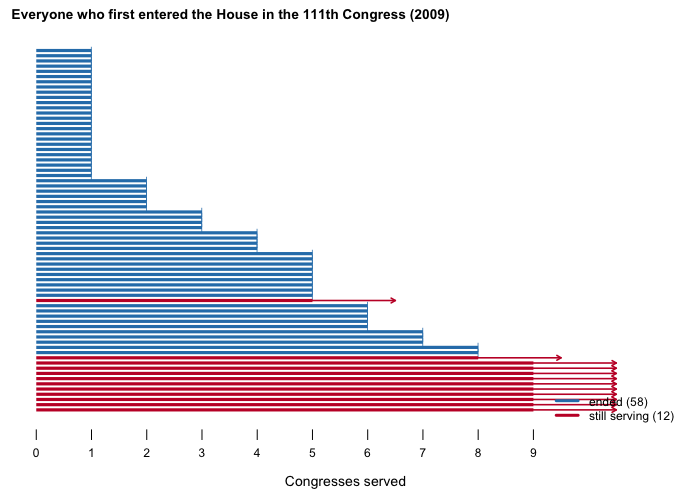

**Figure 1. 70 members, one entering class, 2009.** One bar per career, all starting at the same left edge, because everybody here began together — the form makes the censoring visible as geometry. A bar ending in a tick is a finished career. A bar ending in an arrow is not: 12 of these 70 members were still serving in the 119th Congress. Hover any bar for the member.

Now the question. What is the average career length of this class? The bars that end can be averaged. The arrows cannot, and they are not a small remainder to be swept up, because they are systematically the *long* ones. A career still running at fifteen years is exactly the kind of career that will be long.

Take every career that began in the 104th Congress (elected in 1994, seated in 1995) or later: 1,352 careers, of which 531 (39.3%) are still running. Compute the median three ways.

| Method | What it assumes | Median Congresses |
| --- | --- | --- |
| Count every career, finished or not | that a career still running has already ended | 4 |
| Drop the unfinished careers | that the careers still running are like the ones that ended | 3 |
| Kaplan-Meier | that a career still running is evidence up to today and no further | 6 |

Counting the unfinished careers at their current length says 4. Dropping them says 3. The estimator that handles them says **6**. The two shortcuts do not bracket the right answer; both sit below it, because both, in different ways, throw away the evidence that careers get long.

That error compounds into a false trend, and the trend is the exception this brief exists to tell. Here is every entering cohort, with how much of it is unfinished and the average length of the careers that *have* ended:

| Entered | Years | Careers | Still running | Mean of the ended |
| --- | --- | --- | --- | --- |
| 41th–48th | 1869–1883 | 1,283 | 0.0% | 2.7 |
| 49th–56th | 1885–1899 | 1,263 | 0.0% | 3.2 |
| 57th–64th | 1901–1915 | 1,099 | 0.0% | 4.1 |
| 65th–72th | 1917–1931 | 921 | 0.0% | 4.7 |
| 73th–80th | 1933–1947 | 1,046 | 0.0% | 4.9 |
| 81th–88th | 1949–1963 | 739 | 0.0% | 6.1 |
| 89th–96th | 1965–1979 | 710 | 0.0% | 6.2 |
| 97th–104th | 1981–1995 | 671 | 3.9% | 6.3 |
| 105th–112th | 1997–2011 | 616 | 18.3% | 4.7 |
| 113th–119th | 2013–2025 | 628 | 66.1% | 2.4 |

Read the last column down the page and it looks like a finding: careers grew to about six Congresses by the 1980s and then fell off a cliff, to 2.4 in the newest cohort. Read the column beside it and the finding evaporates. **66.1% of that cohort has not finished**, so the only careers available to average are the ones that ended early. The collapse is a measurement artifact: the longer a career runs, the less likely the record has seen it end.

The Kaplan–Meier estimator does one thing, and it fits in a sentence.[^1] It walks up the lengths in order, asks at each length how many careers were still running and what share of them ended right there, and multiplies those shares together into a survival curve. An unfinished career counts as evidence exactly as far as it is evidence, then leaves without ever being counted as an ending.

Here are its first two steps, from the table `km.csv` holds. All 13,320 careers begin, and 3,826 of them end after one Congress, so the share surviving the first is 71.3%. Going into the second Congress, 9,408 careers are still being watched — not 9,494, because 86 first-term members were still serving in the 119th, and the record can say nothing about their second; they leave the count without being counted as endings. Of those 9,408, 2,601 end, so 72.4% survive *that* step, and the share surviving two Congresses is 71.3% × 72.4% = 51.6%. Repeat up the lengths and the curve is drawn; the median career is the length at which it first drops below half.

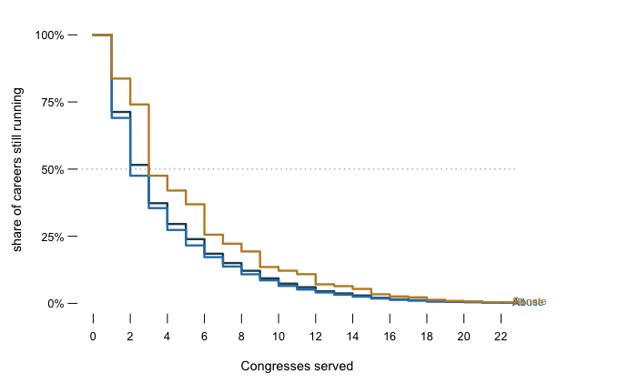

**Figure 2. The share of careers still running, after each number of Congresses.** The dashed line is a half; where a curve crosses it is the median career: 2 Congresses for the House, 3 for the Senate, 3 overall. Hovering gives the estimate and the number of careers still at risk — still running at that length, and so still able to end — which is the honest way to read the right-hand end, where the curve rests on a handful of careers.

So Congress is not a lifetime job. 30.9% of House careers are over after a single Congress — members who arrive in a wave and leave in the next one. The median House career is 2 Congresses, about 4 years. The Senate curve starts higher, with 83.7% surviving the first Congress, and then drops sharply at three, because a senator’s six-year term spans three Congresses: the first point at which a Senate career can end at the ballot box.

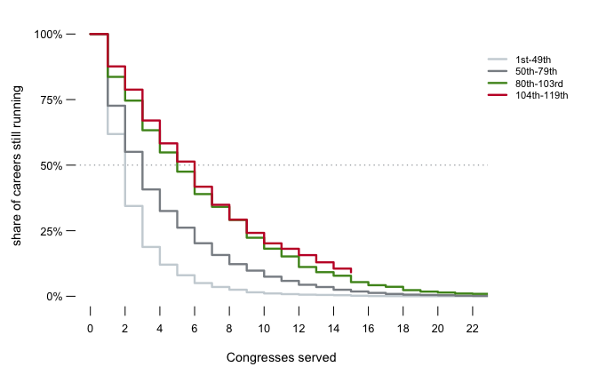

The curves separate in the order the ordinary account of Congress would predict — the House became a career institution over the twentieth century[^2] — and the modern one is the *highest*. A career begun since the 104th Congress has a median of **6 Congresses**, against 3 for one begun between the 50th and the 79th. Careers roughly doubled. Both facts are true at once: the typical career is a few Congresses, not a lifetime, and today’s careers are the longest the record has ever held.

## What this brief cannot tell you

**The estimator assumes the unfinished careers are like the finished ones at the same length**, and that is the one assumption it cannot check. Members still serving may differ from members who left after the same number of Congresses: safer seats, better health, a different era. If they do, the curve is wrong in a direction nothing in the file reveals. Kaplan–Meier is not a way of knowing the future. It is a way of not pretending the future has already happened.

**Nothing here says why a career ended.** Retirement, defeat, a run for another office and death are one event in this file. The retirements and primary-defeats briefs take that question up, and neither can answer it from the membership file alone.

**And every number is relative to the newest Congress in the file.** Rebuild this brief after the next election and every figure moves, not because the past changed but because the record saw more of it.

## Extensions

None of these is answered above, and every one can be answered from the tables the Sources section hands over.

- `naive.csv` shows two wrong ways to count career length, with `what_it_assumes` beside each `median`. Work out which direction each error runs. Which one would a journalist be more likely to publish?
- `careers.csv` flags every career as `ongoing` or finished. Count the ongoing ones. Then compute the median `tenure` with them and without them, and see how far apart the answers are.
- `km.csv` handles the unfinished careers properly, one length at a time. Read `surv` down the column. At what point in a career does the risk of it ending drop away?
- `cohorts.csv` groups careers by when they started and reports `pct_ongoing`. Which cohorts can you say anything reliable about, and which are still being written?

Two stretch ideas point past the spreadsheet. When the 120st Congress convenes, download the updated membership file from Voteview and rebuild: predict which of Figure 3’s curves moves most, and in which direction, before you look. And decide how you would count the members who served in the House and then the Senate — one career or two? Recompute the Senate median under your rule and see what changes.

## Sources

**Data**

- Lewis, Jeffrey B., Keith Poole, Howard Rosenthal, Adam Boche, Aaron Rudkin and Luke Sonnet. *Voteview: Congressional Roll-Call Votes Database.* `HSall_members.csv`, 1st–119th Congresses. https://voteview.com/, downloadable at https://voteview.com/data.

**Academic literature**

- Kaplan, E. L. and Paul Meier (1958). “Nonparametric Estimation from Incomplete Observations.” *Journal of the American Statistical Association* 53(282): 457–481. https://www.jstor.org/stable/2281868. The estimator is written out in four lines of base R and checked against `survival::survfit` every time it runs; it fails rather than publishing a curve that disagrees with the reference implementation.
- Polsby, Nelson W. (1968). “The Institutionalization of the U.S. House of Representatives.” *American Political Science Review* 62(1): 144–168. https://www.jstor.org/stable/1953331.

**The data itself**

Every figure above is drawn from these tables. They are plain CSV, they open in a spreadsheet, and they are yours to take further.

`careers.csv`, `cohorts.csv`, `km.csv`, `naive.csv`, `timeline.csv`

One more file is not data about the subject – it is how this chapter checked its own numbers: `facts.csv`, the individual numbers the text above quotes.

[^1]: E. L. Kaplan and Paul Meier, “Nonparametric Estimation from Incomplete Observations,” *Journal of the American Statistical Association* 53, no. 282 (1958): 457–481, https://www.jstor.org/stable/2281868.
[^2]: The classic statement is Nelson W. Polsby, “The Institutionalization of the U.S. House of Representatives,” *American Political Science Review* 62, no. 1 (1968): 144–168, https://www.jstor.org/stable/1953331.